# home_credite_2020-09

## Table of Content

### 1. Synthesize data for privacy

### 2. MedGAN

### 3. Experiment

### 4. Reference

Home

# Anonymized Synthetic Data Generation by DP-GAN

## 1. Why generation of synthetic data can reserve data privacy?

Many industries from insurance companies to financial institutions to care(health)-providing agencies have access to an ocean of information (in form of structured tabular data) that can be used for making more informed decisions and recognizing new strategies and policies to not only increase their profits but also enhance the quality of their services, resulting in higher customers satisfaction. Machine learning and data mining techniques can effectively extract some data-driven insights from such tremendously large and rich datasets if they can be shared with some third-party research institutions.

Notably, the datasets usually contain an enormous amount of sensitive and personal information and mishandling them can drastically threaten the data privacy of customers. Thus, before sharing these sensitive data with any third-party research institutions, the holders of these datasets have to guarantee and preserve the privacy of their customers' information.

Data anonymization is one of the approaches for preserving data privacy as it aims to make **de-identification attacks** very hard or preferably impossible. In meantime, the anonymized data should preserve the statistical properties and the patterns existed in the original but unprotected data in order to allows ML techniques to extract and learn these patterns for a variety of tasks, such as predictive models. This leads us to a dilemma; **privacy v.s. utility**.

[figure not shown]

Figure1: Utility vs privacy. Image credit:https://aircloak.com/explaining-differential-privacy/

To address both these criteria (privacy v.s. utility), one requires to devise a method to generate **synthetic anonymized data** that I) pertains statistical properties of the original data (measured by a utility metric) while II) preserving the privacy of customers information (which can be quantified by a privacy metric, e.g. DP).

To create such synthetic anonymized data, one can either **fully or partially synthetic data**. In the former, all the features (attributes) of a given dataset are considered as sensitive data, thus analysts should generate fully synthetic data records to be used instead of the original data records. While in the latter, regarding some features as sensitive, the analysts tend to either synthesize values for these attributes or censor them without hurting the utility while keeping the privacy risk, e.g. identity disclosure, low.

## 2. MedGAN: a variant of GAN to generate data from different types

Generally speaking, vanilla GAN learns to estimate the distribution of data, then through sampling from this estimated data distribution, many data samples can be generated. As GAN is originally proposed for image datasets, where the data samples contain real-value features, and is trained regardless of any privacy measurements. However, we aim to generate privacy-preserved synthetic **tabular data** with categorical, discrete, binary or mixed features (data attributes). MedGAN [1] is proposed to generate such discrete-value anonymized features, particularly for medical structured dataset.

In order to generate synthetic discrete-value, the author of MedGAN incorporate an encoder-decoder. The pre-trained encoder ($Enc(\cdot)$) maps each real record represented by $\mathbf{x}\in\mathcal{Z}_{+}^{D}$ (from a $D$-dimensional discrete-value space) into a continuous feature space, then the decoder ($Dec(\cdot)$) maps it back to the discrete-value space. The generator $G(\cdot)$ takes in random prior $\mathbf{z}$ to generate continuous-value feature ($G(\mathbf{z})$), which then maps back to the discrete-value space by $Dec (G(\mathbf{z})) $. Finally, the discriminator is trained to distinguish the generated samples from the real samples.

[figure not shown]

Figure 2: MedGAN for generating discrete-type (categorical) data by incorporating an AutoEncoder

## 3. Experiment

### 3.1. Dataset

We use home credit dataset, a Kaggle dataset for predicting repayment abilities of customers according to some attributes. First, the dataset is pre-processed as follows:

1. **Outlier removal**: Outliers per attribute are detected according to their z-score (z-score>3), then removed.
2. **Data imputation**: using mean and most-frequency strategies, missing values of the real-value and categorical attributes are imputed, respectively.
3. **Encoding categorical attributes** : categorical attributes indicated by string are encoded to be integer type categorical data.
4. **Data standardization** : float-type attributes are standardized to interval $[0,1]$

```python
import os
import sys

import pandas as pd
import matplotlib.pyplot as plt
from sklearn import neighbors as sk_nn
%matplotlib inline
import numpy as np
from sklearn.preprocessing import MinMaxScaler, OneHotEncoder, LabelBinarizer, LabelEncoder
from sklearn.ensemble import RandomForestRegressor
import copy
```

# the procedure for preparing data

```
1. load data, put "target" column as label in a separate df
2. describe() of dataframe to see the values
3. covert data into human-understandable format (negative values in "age" should be converted)
4. outliers detection (visually--box plot, histogram; analytically-- zscore, thresholding)
5. imputation of missing values and outliers
6. mean_normalization of numerical data
7. data transformation of categorical data
```

```python
def plot_box(df):
    i=1
    plt.figure(figsize=(20,20))
    for col in df:
        if df[col].dtypes=='float64':
            plt.subplot(int(len(df)/2),int(len(df)/2), i)
            df[col].plot.box()

            i+=1


def plot_nans(df):
    plt.figure(figsize=(10,6))
    plt.title('missing values for %d features'%len(df.columns))

    plt.plot(range(len(df.columns)),df.isna().sum())

    plt.ticklabel_format(style='sci', axis='y', scilimits=(0,0))
```

```python
tr_data = pd.read_csv('home-credit/application_train.csv')
te_data  = pd.read_csv('home-credit/application_test.csv')
print (len(tr_data), tr_data.columns )
```

```
307511 Index(['SK_ID_CURR', 'TARGET', 'NAME_CONTRACT_TYPE', 'CODE_GENDER',
       'FLAG_OWN_CAR', 'FLAG_OWN_REALTY', 'CNT_CHILDREN', 'AMT_INCOME_TOTAL',
       'AMT_CREDIT', 'AMT_ANNUITY',
       ...
       'FLAG_DOCUMENT_18', 'FLAG_DOCUMENT_19', 'FLAG_DOCUMENT_20',
       'FLAG_DOCUMENT_21', 'AMT_REQ_CREDIT_BUREAU_HOUR',
       'AMT_REQ_CREDIT_BUREAU_DAY', 'AMT_REQ_CREDIT_BUREAU_WEEK',
       'AMT_REQ_CREDIT_BUREAU_MON', 'AMT_REQ_CREDIT_BUREAU_QRT',
       'AMT_REQ_CREDIT_BUREAU_YEAR'],
      dtype='object', length=122)
```

```python
# types of data in dataframe
print (tr_data.dtypes)

print ('===== number of each datatype in dataframe')
print (tr_data.dtypes.value_counts())
print ('=========')

print ('====== number of categories for categorical data')
print (tr_data.select_dtypes('object').apply(pd.Series.nunique, axis = 0))
```

```
SK_ID_CURR                      int64
TARGET                          int64
NAME_CONTRACT_TYPE             object
CODE_GENDER                    object
FLAG_OWN_CAR                   object
                               ...
AMT_REQ_CREDIT_BUREAU_DAY     float64
AMT_REQ_CREDIT_BUREAU_WEEK    float64
AMT_REQ_CREDIT_BUREAU_MON     float64
AMT_REQ_CREDIT_BUREAU_QRT     float64
AMT_REQ_CREDIT_BUREAU_YEAR    float64
Length: 122, dtype: object
===== number of each datatype in dataframe
float64    65
int64      41
object     16
dtype: int64
=========
====== number of categories for categorical data
NAME_CONTRACT_TYPE             2
CODE_GENDER                    3
FLAG_OWN_CAR                   2
FLAG_OWN_REALTY                2
NAME_TYPE_SUITE                7
NAME_INCOME_TYPE               8
NAME_EDUCATION_TYPE            5
NAME_FAMILY_STATUS             6
NAME_HOUSING_TYPE              6
OCCUPATION_TYPE               18
WEEKDAY_APPR_PROCESS_START     7
ORGANIZATION_TYPE             58
FONDKAPREMONT_MODE             4
HOUSETYPE_MODE                 3
WALLSMATERIAL_MODE             7
EMERGENCYSTATE_MODE            2
dtype: int64
```

```
SK_ID_CURR                        0
TARGET                            0
NAME_CONTRACT_TYPE                0
CODE_GENDER                       0
FLAG_OWN_CAR                      0
                              ...
AMT_REQ_CREDIT_BUREAU_DAY     41519
AMT_REQ_CREDIT_BUREAU_WEEK    41519
AMT_REQ_CREDIT_BUREAU_MON     41519
AMT_REQ_CREDIT_BUREAU_QRT     41519
AMT_REQ_CREDIT_BUREAU_YEAR    41519
Length: 122, dtype: int64
```

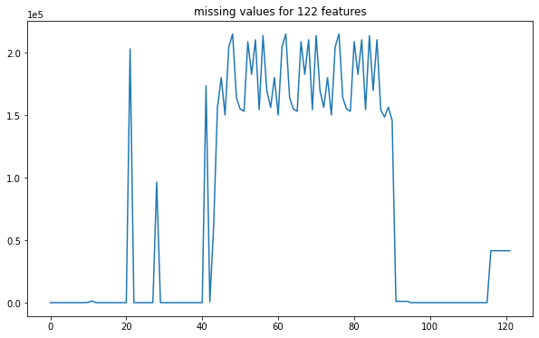

```python
#number of  missing values per attribute
print (tr_data.isna().sum())

plot_nans(tr_data)
```

```python
# step 1
y_tr = tr_data['TARGET']
x_tr = tr_data.drop(['TARGET','SK_ID_CURR'], 1)
x_te = te_data.drop(['SK_ID_CURR'], 1)
x_tr.describe()
```

|  | CNT_CHILDREN | AMT_INCOME_TOTAL | AMT_CREDIT | AMT_ANNUITY | AMT_GOODS_PRICE | REGION_POPULATION_RELATIVE | DAYS_BIRTH | DAYS_EMPLOYED | DAYS_REGISTRATION | DAYS_ID_PUBLISH | ... | FLAG_DOCUMENT_18 | FLAG_DOCUMENT_19 | FLAG_DOCUMENT_20 | FLAG_DOCUMENT_21 | AMT_REQ_CREDIT_BUREAU_HOUR | AMT_REQ_CREDIT_BUREAU_DAY | AMT_REQ_CREDIT_BUREAU_WEEK | AMT_REQ_CREDIT_BUREAU_MON | AMT_REQ_CREDIT_BUREAU_QRT | AMT_REQ_CREDIT_BUREAU_YEAR |
| --- | --- | --- | --- | --- | --- | --- | --- | --- | --- | --- | --- | --- | --- | --- | --- | --- | --- | --- | --- | --- | --- |
| count | 307511.000000 | 3.075110e+05 | 3.075110e+05 | 307499.000000 | 3.072330e+05 | 307511.000000 | 307511.000000 | 307511.000000 | 307511.000000 | 307511.000000 | ... | 307511.000000 | 307511.000000 | 307511.000000 | 307511.000000 | 265992.000000 | 265992.000000 | 265992.000000 | 265992.000000 | 265992.000000 | 265992.000000 |
| mean | 0.417052 | 1.687979e+05 | 5.990260e+05 | 27108.573909 | 5.383962e+05 | 0.020868 | -16036.995067 | 63815.045904 | -4986.120328 | -2994.202373 | ... | 0.008130 | 0.000595 | 0.000507 | 0.000335 | 0.006402 | 0.007000 | 0.034362 | 0.267395 | 0.265474 | 1.899974 |
| std | 0.722121 | 2.371231e+05 | 4.024908e+05 | 14493.737315 | 3.694465e+05 | 0.013831 | 4363.988632 | 141275.766519 | 3522.886321 | 1509.450419 | ... | 0.089798 | 0.024387 | 0.022518 | 0.018299 | 0.083849 | 0.110757 | 0.204685 | 0.916002 | 0.794056 | 1.869295 |
| min | 0.000000 | 2.565000e+04 | 4.500000e+04 | 1615.500000 | 4.050000e+04 | 0.000290 | -25229.000000 | -17912.000000 | -24672.000000 | -7197.000000 | ... | 0.000000 | 0.000000 | 0.000000 | 0.000000 | 0.000000 | 0.000000 | 0.000000 | 0.000000 | 0.000000 | 0.000000 |
| 25% | 0.000000 | 1.125000e+05 | 2.700000e+05 | 16524.000000 | 2.385000e+05 | 0.010006 | -19682.000000 | -2760.000000 | -7479.500000 | -4299.000000 | ... | 0.000000 | 0.000000 | 0.000000 | 0.000000 | 0.000000 | 0.000000 | 0.000000 | 0.000000 | 0.000000 | 0.000000 |
| 50% | 0.000000 | 1.471500e+05 | 5.135310e+05 | 24903.000000 | 4.500000e+05 | 0.018850 | -15750.000000 | -1213.000000 | -4504.000000 | -3254.000000 | ... | 0.000000 | 0.000000 | 0.000000 | 0.000000 | 0.000000 | 0.000000 | 0.000000 | 0.000000 | 0.000000 | 1.000000 |
| 75% | 1.000000 | 2.025000e+05 | 8.086500e+05 | 34596.000000 | 6.795000e+05 | 0.028663 | -12413.000000 | -289.000000 | -2010.000000 | -1720.000000 | ... | 0.000000 | 0.000000 | 0.000000 | 0.000000 | 0.000000 | 0.000000 | 0.000000 | 0.000000 | 0.000000 | 3.000000 |
| max | 19.000000 | 1.170000e+08 | 4.050000e+06 | 258025.500000 | 4.050000e+06 | 0.072508 | -7489.000000 | 365243.000000 | 0.000000 | 0.000000 | ... | 1.000000 | 1.000000 | 1.000000 | 1.000000 | 4.000000 | 9.000000 | 8.000000 | 27.000000 | 261.000000 | 25.000000 |

8 rows × 104 columns

```python
df = x_tr.copy()
df_te = x_te.copy()
# dataset contains 'XNA' as Nan; let to replace them with np.nan
df.replace('XNA', np.NAN, inplace=True)
df.replace('XNA', np.NAN, inplace=True)
```

```python
# step 2: covert negative days values to postive and year format
for c in df.columns:
    if c.startswith('DAYS'):
        df[c]/=-365
```

```python
# step 3: outlier removal
from scipy import stats
plt.figure(figsize=(20,20))
for _ in range(2):

    for col in df:
        if df[col].dtypes=='float':
            a = len(df[col])
            df.drop(index =df[col][(stats.zscore(df[col])>3)].index, axis=0, inplace=True)
            b=len(df[col])
```

```python
#  step 5: data imputation: replace Nans
from sklearn.experimental import enable_iterative_imputer
from sklearn.impute import IterativeImputer, KNNImputer, SimpleImputer

def imputer(df, df_te):
    for col in df:
        if df[col].dtypes=='float64':
    #         imputer = KNNImputer(missing_values=np.nan)
            imputer = SimpleImputer(missing_values = np.nan)

        else:
            imputer = SimpleImputer(missing_values=np.nan, strategy='most_frequent')

        clf = imputer.fit(df[col].values.reshape(-1,1))

        imputed_values = clf.transform (df[col].values.reshape(-1,1))
        df[col] = imputed_values

        imputed_values = clf.transform (df_te[col].values.reshape(-1,1))

        df_te[col] = imputed_values.flatten()
```

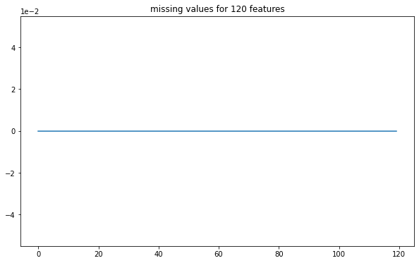

```python
imputer(df,df_te)
# plot to see Nans are removed
plot_nans(df_te)
```

```python
# step 6: normalization of float data

def normalization(train_data, test_data):
    for col in train_data:

        if train_data[col].dtypes =='float64' or train_data[col].dtypes =='object':

            if train_data[col].dtypes =='float64' and len(np.unique(train_data[col]))>2:

                # transform into [0,1]
                f = MinMaxScaler()
                f.fit( train_data[col].values.reshape(-1,1))
                tr = f.transform(train_data[col].values.reshape(-1,1))
                te = f.transform(test_data[col].values.reshape(-1,1))

            elif train_data[col].dtypes =='object':

                f = LabelEncoder()

#                 unseen category in test data forces me to concatenate test and train togther
                f.fit( pd.concat((train_data[col],test_data[col]),axis=0))
                tr = f.transform(train_data[col])
                te = f.transform(test_data[col])


            train_data[col] = tr.flatten()
            test_data[col] = te.flatten()
```

```python
normalization(df, df_te)
```

```python
df.to_csv('Processed_train_house.csv')
df_te.to_csv('Processed_test_house.csv')
```

```python
df.info()
```

```
<class 'pandas.core.frame.DataFrame'>
Int64Index: 288352 entries, 0 to 307510
Columns: 120 entries, NAME_CONTRACT_TYPE to AMT_REQ_CREDIT_BUREAU_YEAR
dtypes: float64(68), int64(52)
memory usage: 276.2 MB
```